# Summary

# 3/Model diagnostic

A diagnostic plot of the model is included in annexes Fig.7. The residuals vs. fitted plot shows no systematic pattern. Let’s check the Variance Inflation Factor (VIF) to see if the variance has been inflated by the addition of weight variable.

```r
sqrt(vif(fit21))
```

```
##       am       wt    am:wt
## 4.571789 1.651741 3.920058
```

Here we see that am and am:wt have high VIF and are correlated, which is expected, and that wt has a low VIF.

# 4/Uncertainty and confidence intervals

The 95% confidence intervals of the coefficient are determined below.

```r
confint(fit21)
```

```
##                 2.5 %    97.5 %
## (Intercept) 25.229642 37.602469
## am1          6.143928 23.612917
## wt          -5.395234 -2.176581
## am1:wt      -8.257693 -2.339028
```

## ANNEXES

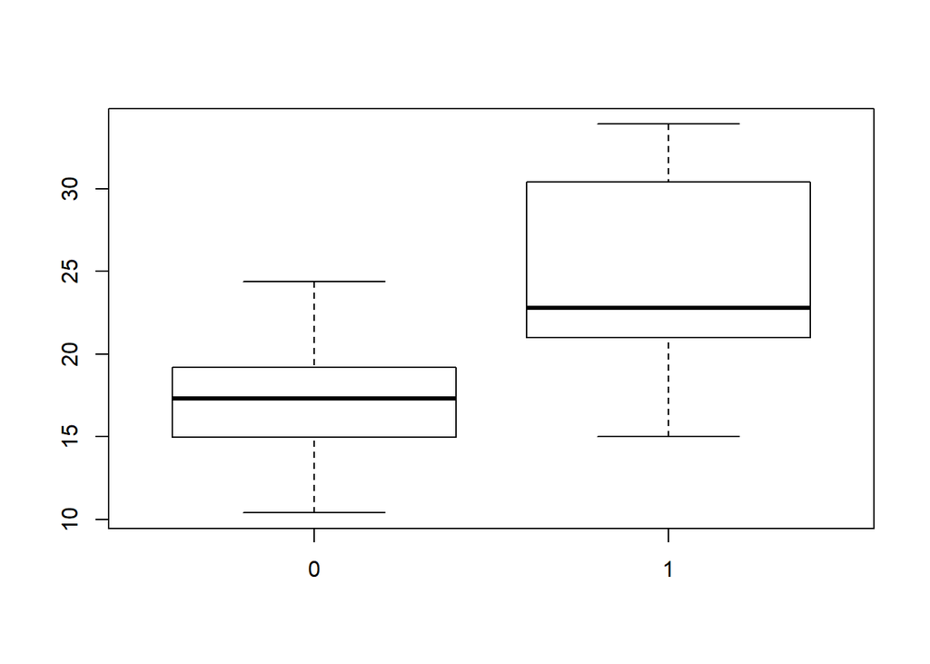

```r
plot(data$am,data$mpg)
```

Fig.1: Boxplot mpg for manual (1) and automatic (0) cars

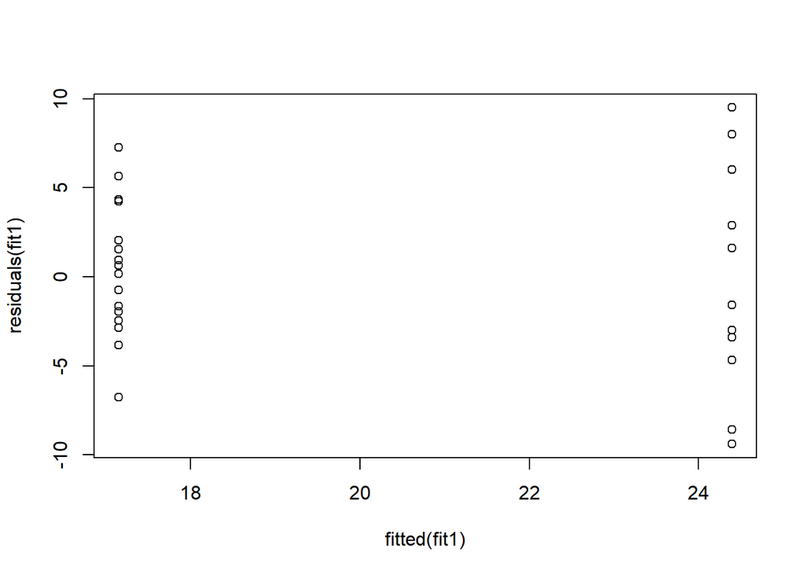

```r
plot(fitted(fit1),residuals(fit1))
```

Fig. 2: Residual vs. Fitted model fit1

Fig.3: coefficients of fit1

```r
summary(fit1)$coef
```

```
##              Estimate Std. Error   t value     Pr(>|t|)
## (Intercept) 17.147368   1.124603 15.247492 1.133983e-15
## am1          7.244939   1.764422  4.106127 2.850207e-04
```

Fig.4: Anova coefficients

```r
anova(fit1, fit2, fit3,fit4, fit5, fit6,fit7,fit8,fit9,fit10)[1:6]
```

```
##    Res.Df    RSS Df Sum of Sq       F    Pr(>F)
## 1      30 720.90
## 2      29 278.32  1    442.58 55.1371 2.129e-06 ***
## 3      28 180.29  1     98.03 12.2126  0.003259 **
## 4      26 151.03  2     29.27  1.8230  0.195569
## 5      25 150.41  1      0.62  0.0768  0.785409
## 6      24 150.10  1      0.31  0.0384  0.847256
## 7      23 141.21  1      8.89  1.1081  0.309157
## 8      22 139.02  1      2.18  0.2719  0.609644
## 9      20 134.00  2      5.02  0.3128  0.736057
## 10     15 120.40  5     13.60  0.3388  0.881444
## ---
## Signif. codes:  0 '***' 0.001 '**' 0.01 '*' 0.05 '.' 0.1 ' ' 1
```

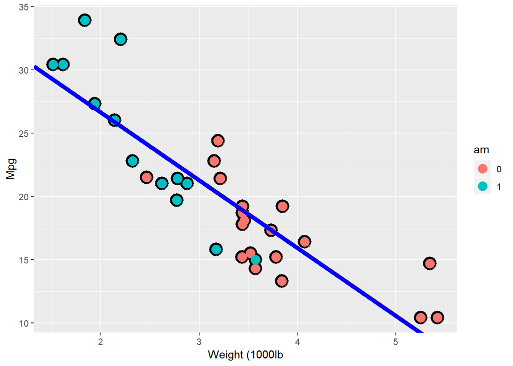

```r
g = ggplot(data, aes(x = wt, y = mpg, colour = am))
g = g + geom_point(size = 6, colour = "black") + geom_point(size = 4)
g = g + xlab("Weight (1000lb") + ylab("Mpg")
g1 = g
g1 = g1 + geom_abline(intercept = coef(fit2)[1], slope = coef(fit2)[3], size = 2,colour="orange")
g1 = g1 + geom_abline(intercept = coef(fit2)[1] + coef(fit2)[2],
                          slope = coef(fit2)[3], size = 2,colour="blue")
g1
```

Fig.5: Regression lines of fit2 mpg~am+wt

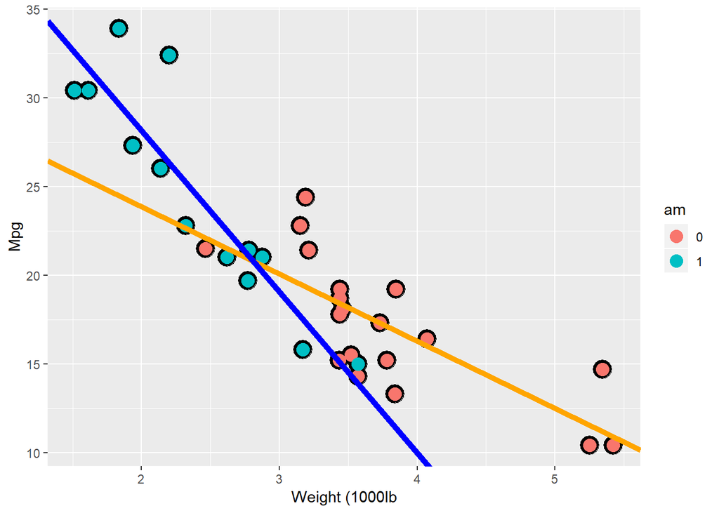

```r
g2 = g
g2 = g2 + geom_abline(intercept = coef(fit21)[1], slope = coef(fit21)[3], size = 2,colour="orange")
g2 = g2 + geom_abline(intercept = coef(fit21)[1] + coef(fit21)[2],
                          slope = coef(fit21)[3] + coef(fit21)[4], size = 2,colour="blue")
g2
```

Fig.6: Regression lines model fit21 mpg~am*wt includng interaction terms.

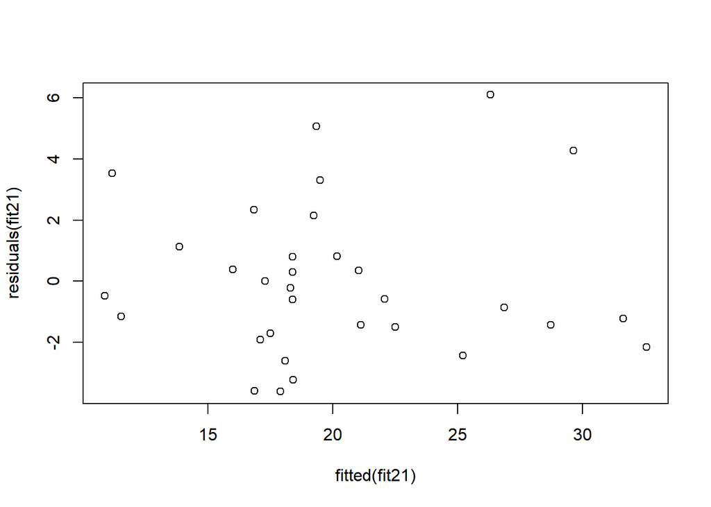

```r
plot(fitted(fit21),residuals(fit21))
```

Fig.7: diagnostic plot of fit21 mpg~am*wt